# Act Report

#### Chloe Xue June 2019

- Introduction
- Project Introduction
- Dataset Introduction
- Analysis and Visualiztions
- Plot 1. Rating Distribution
- Plot 2. Correlation Plot
- Linear Regression: Analysis on Rating Preditcion
- Plot 3. Retweet/Favorite on Rating
- Plot 4. Popularity on Dog Stage
- Plot 5. Source Plot
- Plot 6. Dog Breed Ranking
- Plot 7. Breed Prediction Ranking

### Project Introduction

> In this project, the dataset I analyze is the tweet archive of Twitter user [@dog_rates](https://twitter.com/dog_rates), also known as WeRateDogs. This twitter account rates people's dogs with ratings on denominator of 10 along with comments. This archive contains basic tweet data (tweet ID, timestamp, text, etc.) for all 5000+ of tweets from August 1, 2017.

> The objective of this analysis is to provide communications on findings of WeRateDogs data, deliver insightful and interesting information in visual-clear method with interpretable results.

### Dataset Introduction

Original dataset:

- Twittwer Archive. Originally the enhanced Twitter archive contains 5000+ tweets with basic tweet data. It is being filtered for tweets with ratings only along with information like dog name, stage, etc.
- Image Prediction. This dataset is created by running every image in the WeRateDogs Twitter Archive through a neural network that can classify top three predictions(corresponding to the most confident predictions) on breeds of dogs alongside each tweet ID, image URL and the image number.
- Retweets and Favorites.Querying from Twitter's API, this dataset generates retweet count and favorite count of each tweet ID in WeRateDogs Twitter Archive.

Final dataset after wrangling:

- Final dataframe is saved as twitter_archive_master in csv file with columns: {tweet_id, timestamp, text, rating_numerator, rating_denominator, name, dog_type, dog_breed, confidence, dog_stage, retweet_count, favorite_count, source.}

## Analysis and Visualizations

### Plot 1. Rating Distrition: How does 'WeRateDogs' rate dogs on scores?

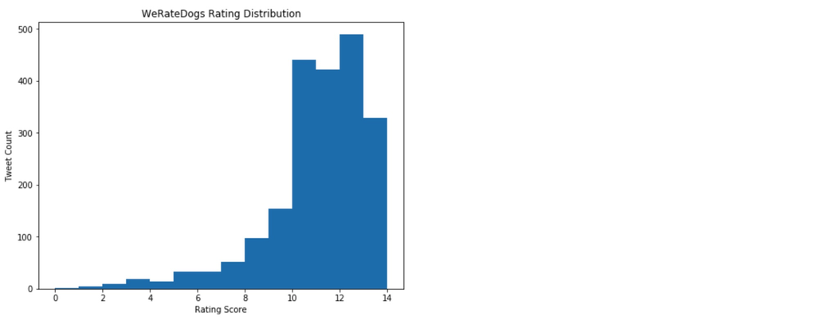

As you can see from the plot, 80% of dogs rated in the range of 10 and 13. The highest rating score is 14, involving 2% of dog pictures. Pictures could be rated to zero, due to the reason that people are not sending dog pictures. Scary dogs and not-looking-good pictures could be rated low. WeRateDogs rates dog pictures with both good and bad comments.

### Plot 2. Correlation Plot: If a tweet is retweetd a lot, is it being favorited a lot meantime?

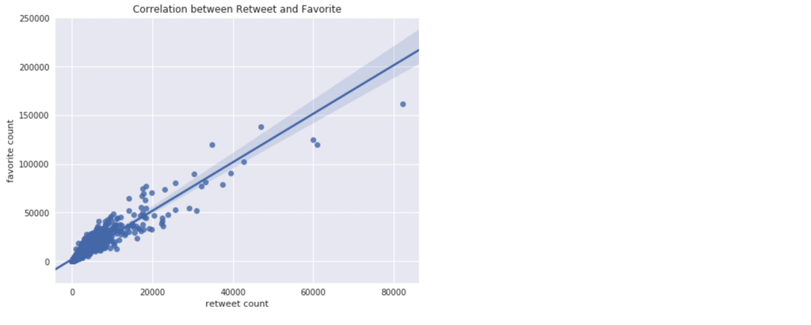

With a Pearson Correlation Coefficient 0.9272, data shows a strong evidence that retweet count and favorite count on WeRateDogs tweets positively impact on each other. If a tweet is retweeted a lot, its favorite count is also high. Numbers on favorite count are generally greater than retweet count. People tend to favorite more than retweet.

### Linear Regression: If a tweet being retweeted and favorite a lot, does it mean it has a high rating?'

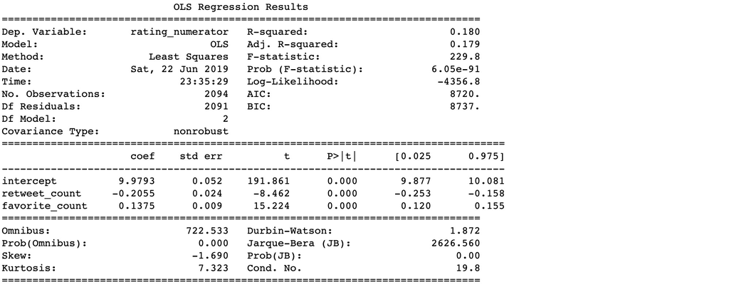

I use retweet and favorite count as predictor variable to build a linear regression model to predict rating score. Reading from model results, p-values for two predictor variables, retweet and favorite are zero. It indicates that number of favorite count will positively predict a rating score. That means, if number of favorite count is higher, with retweet count holds one unit lower, rating score is higher.

### Plot 3. Retweet/Favorite on Rating Score Plot: Will highly rated dogs cause big trend on retweet and favorite?

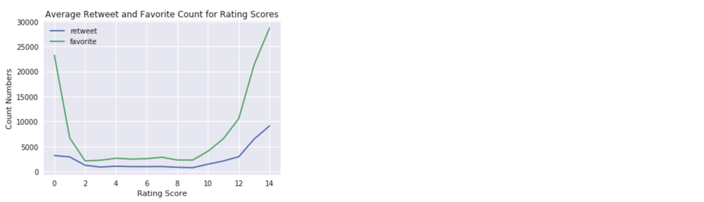

Two interesting findings from the plot: One is when the rating score is zero, favorite count reaches about 23000 which is rare. One of the reason is the picture is not a dog picture.

Second finding is, if WeRateDogs rates a dog picture with 9 or above, number of retweet and favorite count will increase.

### Plot 4. Popularity on Three Dimensions(Retweet, Favorite and Rating) on dog stage: People like young dog better or old dog better?

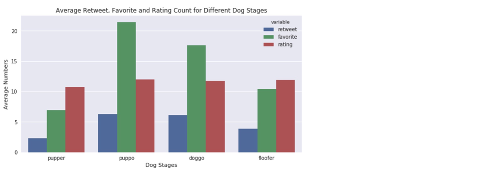

pupper is the youngest dog stage and doggo is the oldest stage. Both users on Twitter and WeRateDogs account like teeanager dogs (puppo) the best. The popularity towards furry dog (floofer) is neutral.

### Plot 5. Where are tweets coming from?

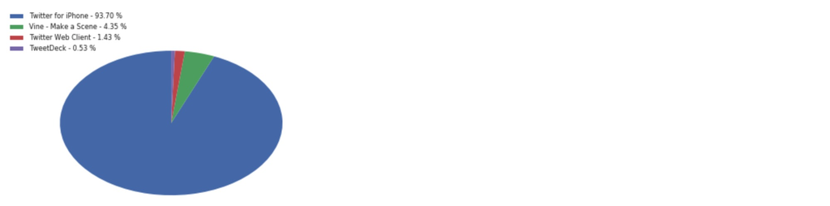

93.7% of tweets are coming from iPhone. People also tweet using Vine, Web Client and TweetDeck.

### Plot 6. What are the dog breeds that are tweeted most and rated highest on WeRateDogs?

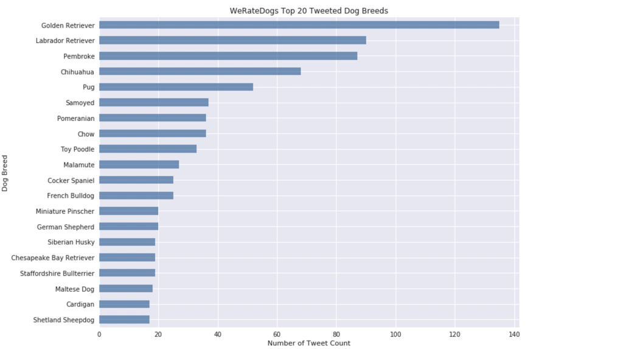

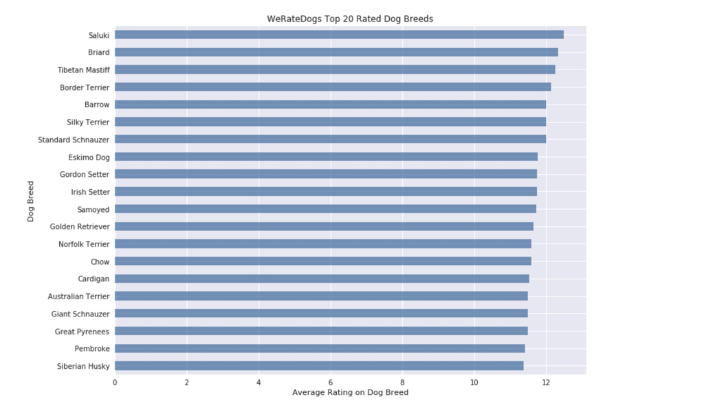

- From the most tweeted dog breed ranking: WeRateDogs rates most on picures of Golden Retriever, Labrador Retriever, Pembroke, Chihuahua and Pug.
- From the highest rated dog breed ranking: WeRateDogs gives high rating on pictures of Saluki, Briard, Tibetan Matstiff. Border Terrier and Barrow.
- Golden Retriever and Pembroke gain a general likability from public: lots of people raise those two breeds and they gain high rating.

### Plot 7. What kinds of dog breed are confidently to predict?

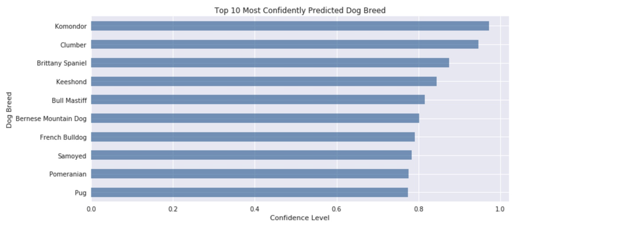

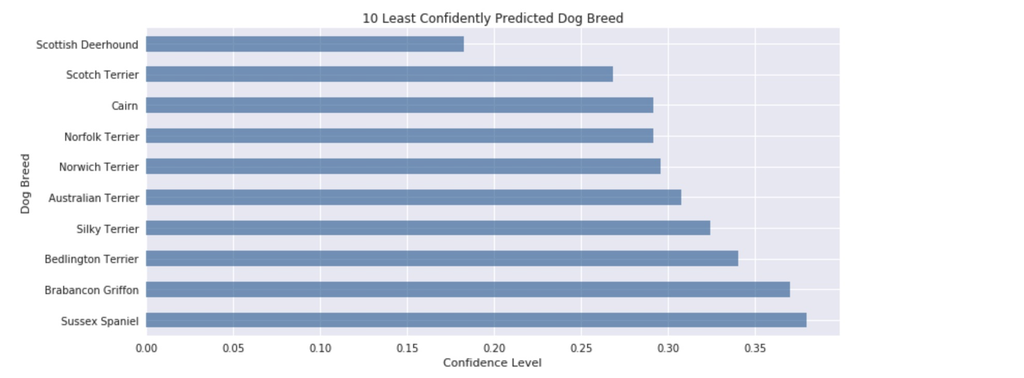